# Lab 1

Author

Dominic Wooldridge

Published

September 28, 2025

# Task 1

*1.1:*

In the bubble chart, the aesthetics are set to:

x = income per person

y = life expectancy

size = population

color = world region

*1.2:*

```python
import pandas as pd
q1 = pd.read_csv("C:/Users/Owner/Downloads/MSBA RStudio/GSB S544/Lab 1/q1data.csv")
q1
```

|  | income | life_exp | population | year | country | four_regions | six_regions | eight_regions | world_bank_region |
| --- | --- | --- | --- | --- | --- | --- | --- | --- | --- |
| 0 | 1910.0 | 61.0 | 29200000.0 | 2010 | Afghanistan | asia | south_asia | asia_west | South Asia |
| 1 | 11100.0 | 78.1 | 2950000.0 | 2010 | Albania | europe | europe_central_asia | europe_east | Europe & Central Asia |
| 2 | 11100.0 | 74.7 | 36000000.0 | 2010 | Algeria | africa | middle_east_north_africa | africa_north | Middle East & North Africa |
| 3 | 46900.0 | 81.9 | 84500.0 | 2010 | Andorra | europe | europe_central_asia | europe_west | Europe & Central Asia |
| 4 | 7680.0 | 60.8 | 23400000.0 | 2010 | Angola | africa | sub_saharan_africa | africa_sub_saharan | Sub-Saharan Africa |
| ... | ... | ... | ... | ... | ... | ... | ... | ... | ... |
| 192 | 20400.0 | 75.4 | 28400000.0 | 2010 | Venezuela | americas | america | america_south | Latin America & Caribbean |
| 193 | 5350.0 | 73.3 | 88000000.0 | 2010 | Vietnam | asia | east_asia_pacific | east_asia_pacific | East Asia & Pacific |
| 194 | 4700.0 | 67.8 | 23200000.0 | 2010 | Yemen | asia | middle_east_north_africa | asia_west | Middle East & North Africa |
| 195 | 3200.0 | 57.5 | 13600000.0 | 2010 | Zambia | africa | sub_saharan_africa | africa_sub_saharan | Sub-Saharan Africa |
| 196 | 2560.0 | 54.4 | 12700000.0 | 2010 | Zimbabwe | africa | sub_saharan_africa | africa_sub_saharan | Sub-Saharan Africa |

197 rows × 9 columns

*1.3:*

```python
q1_clean = q1.copy()
q1_clean['income'] = pd.to_numeric(q1_clean['income'], errors='coerce')
q1_clean = q1_clean.query('income > 0')
q1_clean = q1_clean.dropna(subset=['life_exp','population','four_regions'])
q1_clean['four_regions'] = q1_clean['four_regions'].astype('category')
q1_clean
```

|  | income | life_exp | population | year | country | four_regions | six_regions | eight_regions | world_bank_region |
| --- | --- | --- | --- | --- | --- | --- | --- | --- | --- |
| 0 | 1910.0 | 61.0 | 29200000.0 | 2010 | Afghanistan | asia | south_asia | asia_west | South Asia |
| 1 | 11100.0 | 78.1 | 2950000.0 | 2010 | Albania | europe | europe_central_asia | europe_east | Europe & Central Asia |
| 2 | 11100.0 | 74.7 | 36000000.0 | 2010 | Algeria | africa | middle_east_north_africa | africa_north | Middle East & North Africa |
| 3 | 46900.0 | 81.9 | 84500.0 | 2010 | Andorra | europe | europe_central_asia | europe_west | Europe & Central Asia |
| 4 | 7680.0 | 60.8 | 23400000.0 | 2010 | Angola | africa | sub_saharan_africa | africa_sub_saharan | Sub-Saharan Africa |
| ... | ... | ... | ... | ... | ... | ... | ... | ... | ... |
| 192 | 20400.0 | 75.4 | 28400000.0 | 2010 | Venezuela | americas | america | america_south | Latin America & Caribbean |
| 193 | 5350.0 | 73.3 | 88000000.0 | 2010 | Vietnam | asia | east_asia_pacific | east_asia_pacific | East Asia & Pacific |
| 194 | 4700.0 | 67.8 | 23200000.0 | 2010 | Yemen | asia | middle_east_north_africa | asia_west | Middle East & North Africa |
| 195 | 3200.0 | 57.5 | 13600000.0 | 2010 | Zambia | africa | sub_saharan_africa | africa_sub_saharan | Sub-Saharan Africa |
| 196 | 2560.0 | 54.4 | 12700000.0 | 2010 | Zimbabwe | africa | sub_saharan_africa | africa_sub_saharan | Sub-Saharan Africa |

191 rows × 9 columns

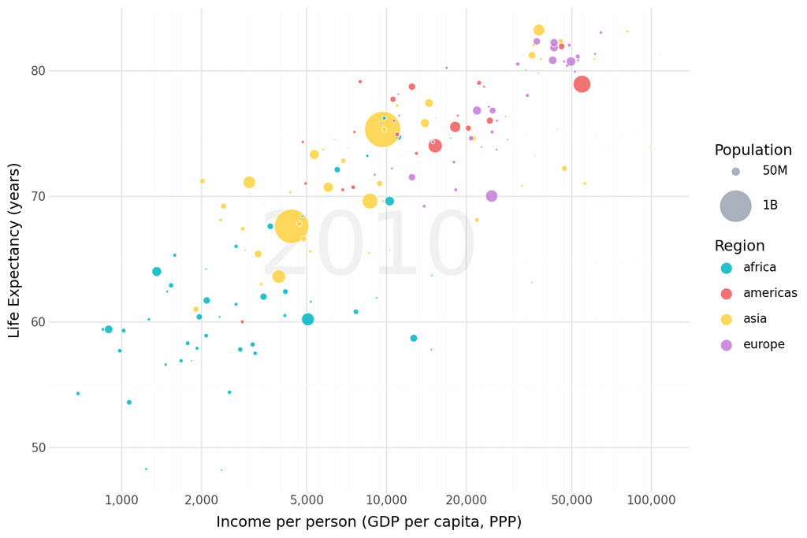

```python
import numpy as np
from mizani.formatters import comma_format
from plotnine import (
    ggplot, aes, geom_point, annotate, labs, theme_minimal, theme,
    scale_x_log10, scale_size_area, scale_fill_manual, guides
)
from plotnine.guides import guide_legend

# region colors
gap_colors = {'africa':'#00B5C4','americas':'#EF5A5A','asia':'#FFD23F','europe':'#C67AD9'}

x_breaks = [1e3, 2e3, 5e3, 1e4, 2e4, 5e4, 1e5]

p = (
    ggplot(q1_clean, aes(x='income', y='life_exp', size='population', fill='four_regions'))
    + annotate('text',
               x=np.sqrt(q1_clean['income'].min()*q1_clean['income'].max()),
               y=(q1_clean['life_exp'].min()+q1_clean['life_exp'].max())/2,
               label='2010', size=70, alpha=0.08, color='#4d4d4d')
    + geom_point(alpha=0.85, color='white', stroke=0.35)
    + scale_x_log10(breaks=x_breaks, labels=comma_format())
    + scale_size_area(max_size=16, breaks=[5e7, 1e9], labels=['50M','1B'], guide='legend')
    + scale_fill_manual(values=gap_colors)
    + labs(x='Income per person (GDP per capita, PPP)',
           y='Life Expectancy (years)', fill='Region', size='Population')
    + guides(
        size=guide_legend(order=1,
                          override_aes={'fill':'#9aa4b2','color':'#9aa4b2','alpha':0.85,'stroke':0.3}),
        fill=guide_legend(order=2,
                          override_aes={'size':5,'stroke':0.3,'color':'white'})
    )
    + theme_minimal(base_size=12)
    + theme(figure_size=(9,6))
)
p
```

*1.4:*

I used geom_bin2d to show a 2d density plot of where the data is located. Though this representation is informative, I feel that the bubble plot is a lot easier to interpret, mainly due to the color scale and separation of the observations.

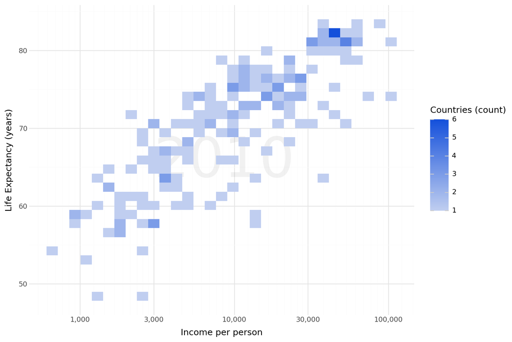

```python
from plotnine import (
    ggplot, aes, geom_bin2d, annotate, labs, theme_minimal, theme,
    scale_x_log10, scale_fill_gradient
)
from mizani.breaks import log_breaks
from mizani.formatters import comma_format
import numpy as np

df = q1_clean

p_alt = (
    ggplot(df, aes(x='income', y='life_exp'))
    + annotate('text',
               x=np.sqrt(df['income'].min()*df['income'].max()),
               y=(df['life_exp'].min()+df['life_exp'].max())/2,
               label='2010', size=70, alpha=0.08, color='#4d4d4d')
    + geom_bin2d(bins=30)
    + scale_x_log10(breaks=log_breaks(n=6), labels=comma_format())
    + scale_fill_gradient(low='#C0CEF0', high='#1450DB')
    + labs(x='Income per person',
           y='Life Expectancy (years)',
           fill='Countries (count)')
    + theme_minimal() + theme(figure_size=(9,6))
)

p_alt
```

# Task 2

*2.1:*

In the bubble chart, the aesthetics are set to:

x = exports (% of GDP)

y = imports (% of GDP)

size = energy use

color = world region

*2.2:*

```python
q2 = pd.read_csv("C:/Users/Owner/Downloads/MSBA RStudio/GSB S544/Lab 1/q2data.csv")
q2
```

|  | imports | exports | energy | year | country | four_regions | six_regions | eight_regions | world_bank_region |
| --- | --- | --- | --- | --- | --- | --- | --- | --- | --- |
| 0 | NaN | NaN | NaN | 1997 | Afghanistan | asia | south_asia | asia_west | South Asia |
| 1 | 36.7 | 11.5 | 427 | 1997 | Albania | europe | europe_central_asia | europe_east | Europe & Central Asia |
| 2 | 22.5 | 22.6 | 825 | 1997 | Algeria | africa | middle_east_north_africa | africa_north | Middle East & North Africa |
| 3 | NaN | NaN | NaN | 1997 | American Samoa | NaN | NaN | NaN | NaN |
| 4 | NaN | NaN | 434 | 1997 | Angola | africa | sub_saharan_africa | africa_sub_saharan | Sub-Saharan Africa |
| ... | ... | ... | ... | ... | ... | ... | ... | ... | ... |
| 201 | 52.2 | 44.8 | 340 | 1997 | Vietnam | asia | east_asia_pacific | east_asia_pacific | East Asia & Pacific |
| 202 | NaN | NaN | NaN | 1997 | Virgin Islands (U.S.) | NaN | NaN | NaN | NaN |
| 203 | NaN | NaN | 241 | 1997 | Yemen | NaN | NaN | NaN | NaN |
| 204 | 31.6 | 24.6 | 617 | 1997 | Zambia | africa | sub_saharan_africa | africa_sub_saharan | Sub-Saharan Africa |
| 205 | 45.1 | 43.4 | 845 | 1997 | Zimbabwe | africa | sub_saharan_africa | africa_sub_saharan | Sub-Saharan Africa |

206 rows × 9 columns

*2.3:*

```python
q2c = q2.copy()
for col in ['imports', 'exports', 'energy']:
    q2c[col] = (
        q2c[col]
        .astype(str)
        .str.replace('%', '', regex=False)
        .str.replace(',', '', regex=False)
    )
    q2c[col] = pd.to_numeric(q2c[col], errors='coerce')

q2c['four_regions'] = q2c['four_regions'].str.strip().str.lower()
q2c = q2c.dropna(subset=['imports', 'exports', 'energy', 'four_regions'])

q2c = q2c.query('exports > 0 and energy > 0')

q2c['four_regions'] = q2c['four_regions'].astype('category')

q2c
```

|  | imports | exports | energy | year | country | four_regions | six_regions | eight_regions | world_bank_region |
| --- | --- | --- | --- | --- | --- | --- | --- | --- | --- |
| 1 | 36.7 | 11.5 | 427.0 | 1997 | Albania | europe | europe_central_asia | europe_east | Europe & Central Asia |
| 2 | 22.5 | 22.6 | 825.0 | 1997 | Algeria | africa | middle_east_north_africa | africa_north | Middle East & North Africa |
| 6 | 12.9 | 10.4 | 1660.0 | 1997 | Argentina | americas | america | america_south | Latin America & Caribbean |
| 7 | 52.8 | 19.0 | 610.0 | 1997 | Armenia | europe | europe_central_asia | europe_east | Europe & Central Asia |
| 9 | 20.5 | 19.6 | 5550.0 | 1997 | Australia | asia | east_asia_pacific | east_asia_pacific | East Asia & Pacific |
| ... | ... | ... | ... | ... | ... | ... | ... | ... | ... |
| 198 | 22.9 | 22.6 | 2080.0 | 1997 | Uzbekistan | asia | europe_central_asia | asia_west | Europe & Central Asia |
| 200 | 22.7 | 20.9 | 2250.0 | 1997 | Venezuela | americas | america | america_south | Latin America & Caribbean |
| 201 | 52.2 | 44.8 | 340.0 | 1997 | Vietnam | asia | east_asia_pacific | east_asia_pacific | East Asia & Pacific |
| 204 | 31.6 | 24.6 | 617.0 | 1997 | Zambia | africa | sub_saharan_africa | africa_sub_saharan | Sub-Saharan Africa |
| 205 | 45.1 | 43.4 | 845.0 | 1997 | Zimbabwe | africa | sub_saharan_africa | africa_sub_saharan | Sub-Saharan Africa |

125 rows × 9 columns

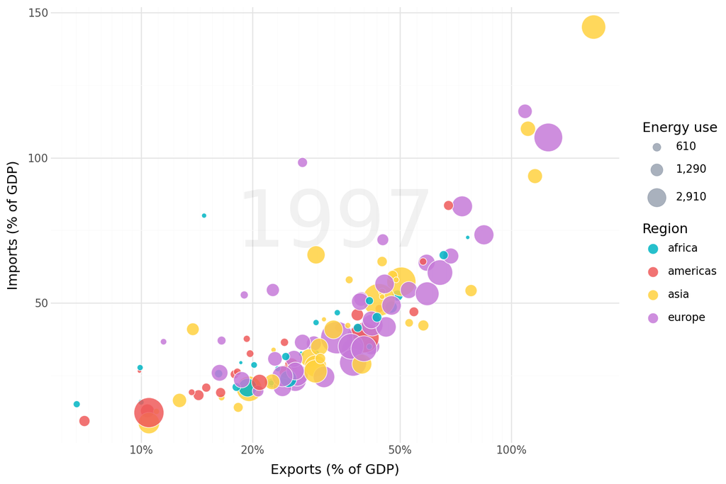

```python
gap_colors = {'africa':'#00B5C4','americas':'#EF5A5A','asia':'#FFD23F','europe':'#C67AD9'}

energy_brks = list(np.quantile(q2c['energy'], [0.25, 0.5, 0.75]))

p = (
    ggplot(q2c, aes(x='exports', y='imports', size='energy', fill='four_regions'))
    + annotate('text',
               x=np.sqrt(q2c['exports'].min()*q2c['exports'].max()),
               y=(q2c['imports'].min()+q2c['imports'].max())/2,
               label='1997', size=70, alpha=0.08, color='#4d4d4d')
    + geom_point(alpha=0.85, color='white', stroke=0.35)
    + scale_x_log10(breaks=[1, 2, 5, 10, 20, 50, 100],
                    labels=lambda b: [f'{v:g}%' for v in b])
    + scale_size_area(max_size=16, breaks=energy_brks,
                      labels=[f'{int(x):,}' for x in energy_brks],
                      guide='legend')
    + scale_fill_manual(values=gap_colors)
    + labs(x='Exports (% of GDP)', y='Imports (% of GDP)',
           fill='Region', size='Energy use')
    + guides(
        size=guide_legend(order=1,
                          override_aes={'fill':'#9aa4b2','color':'#9aa4b2','alpha':0.85,'stroke':0.3}),
        fill=guide_legend(order=2,
                          override_aes={'size':5,'stroke':0.3,'color':'white'})
    )
    + theme_minimal(base_size=12)
    + theme(figure_size=(9,6))
)

p
```

*2.4:*

For an alternative geometry, I chose geom_density_2d. This geometry is much less intuitive than the bubble plot. This plot is good at highlighting the overall pattern of the data, but the overlapping can be hard to interpret.

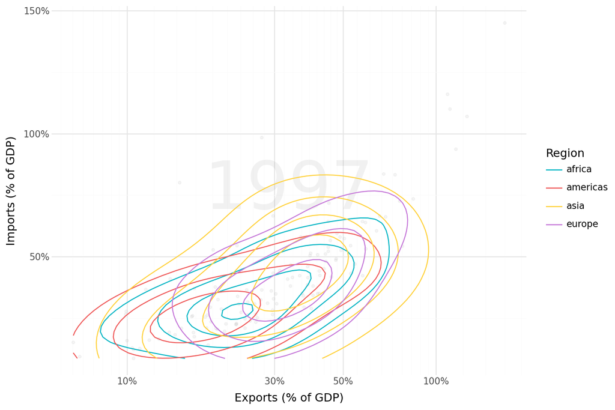

```python
from plotnine import (
    ggplot, aes, geom_point, geom_density_2d, annotate, labs, theme_minimal, theme,
    scale_x_log10, scale_y_continuous, scale_color_manual
)
from mizani.breaks import log_breaks
import numpy as np

gap_colors = {'africa':'#00B5C4','americas':'#EF5A5A','asia':'#FFD23F','europe':'#C67AD9'}

p_alt = (
    ggplot(q2c, aes(x='exports', y='imports'))
    + annotate('text',
               x=np.sqrt(q2c['exports'].min()*q2c['exports'].max()),
               y=(q2c['imports'].min()+q2c['imports'].max())/2,
               label='1997', size=70, alpha=0.08, color='#4d4d4d')
    + geom_point(alpha=0.15, size=1.2, color='#bdbdbd')
    + geom_density_2d(aes(color='four_regions'), size=0.6)
    + scale_color_manual(values=gap_colors)
    + scale_x_log10(breaks=log_breaks(n=6), labels=lambda b: [f'{v:g}%' for v in b])
    + scale_y_continuous(labels=lambda b: [f'{v:g}%' for v in b])
    + labs(x='Exports (% of GDP)', y='Imports (% of GDP)', color='Region')
    + theme_minimal(base_size=12)
    + theme(figure_size=(9,6))
)

p_alt
```

# Task 3

*3.1:*

In the bubble chart, the aesthetics are set to:

x = individuals using the internet

y = GDP per capita

size = income

color = world region

*3.2:*

```python
q3 = pd.read_csv("C:/Users/Owner/Downloads/MSBA RStudio/GSB S544/Lab 1/q3data.csv")
q3
```

|  | internet_users | gdp | income | year | country | four_regions | six_regions | eight_regions | world_bank_region |
| --- | --- | --- | --- | --- | --- | --- | --- | --- | --- |
| 0 | 0.00456 | 330.0 | 1190.0 | 2001 | Afghanistan | asia | south_asia | asia_west | South Asia |
| 1 | 0.39000 | 2570.0 | 6780.0 | 2001 | Albania | europe | europe_central_asia | europe_east | Europe & Central Asia |
| 2 | 1.59000 | 3770.0 | 9230.0 | 2001 | Algeria | africa | middle_east_north_africa | africa_north | Middle East & North Africa |
| 3 | NaN | 10500.0 | NaN | 2001 | American Samoa | NaN | NaN | NaN | NaN |
| 4 | 11.30000 | 42600.0 | 35600.0 | 2001 | Andorra | europe | europe_central_asia | europe_west | Europe & Central Asia |
| ... | ... | ... | ... | ... | ... | ... | ... | ... | ... |
| 210 | 1.85000 | 847.0 | 3270.0 | 2001 | Vietnam | asia | east_asia_pacific | east_asia_pacific | East Asia & Pacific |
| 211 | 27.50000 | 36700.0 | NaN | 2001 | Virgin Islands (U.S.) | NaN | NaN | NaN | NaN |
| 212 | 0.51900 | 1190.0 | 4940.0 | 2001 | Yemen | asia | middle_east_north_africa | asia_west | Middle East & North Africa |
| 213 | 0.47800 | 991.0 | 2080.0 | 2001 | Zambia | africa | sub_saharan_africa | africa_sub_saharan | Sub-Saharan Africa |
| 214 | 1.10000 | 1330.0 | 3190.0 | 2001 | Zimbabwe | africa | sub_saharan_africa | africa_sub_saharan | Sub-Saharan Africa |

215 rows × 9 columns

*3.3:*

```python
q3c = q3.copy()

for col in ['internet_users', 'gdp', 'income']:
    q3c[col] = (
        q3c[col].astype(str)
                 .str.replace('%','', regex=False)
                 .str.replace(',','', regex=False)
    )
    q3c[col] = pd.to_numeric(q3c[col], errors='coerce')


q3c['four_regions'] = q3c['four_regions'].astype(str).str.strip().str.lower()
q3c = q3c.dropna(subset=['internet_users', 'gdp', 'income', 'four_regions'])

q3c = q3c.query('gdp > 0 and income > 0 and internet_users >= 0')
q3c = q3c[q3c['internet_users'] <= 100]

q3c['four_regions'] = q3c['four_regions'].astype('category')

q3c
```

|  | internet_users | gdp | income | year | country | four_regions | six_regions | eight_regions | world_bank_region |
| --- | --- | --- | --- | --- | --- | --- | --- | --- | --- |
| 0 | 0.00456 | 330.0 | 1190.0 | 2001 | Afghanistan | asia | south_asia | asia_west | South Asia |
| 1 | 0.39000 | 2570.0 | 6780.0 | 2001 | Albania | europe | europe_central_asia | europe_east | Europe & Central Asia |
| 2 | 1.59000 | 3770.0 | 9230.0 | 2001 | Algeria | africa | middle_east_north_africa | africa_north | Middle East & North Africa |
| 4 | 11.30000 | 42600.0 | 35600.0 | 2001 | Andorra | europe | europe_central_asia | europe_west | Europe & Central Asia |
| 5 | 0.27000 | 2440.0 | 2900.0 | 2001 | Angola | africa | sub_saharan_africa | africa_sub_saharan | Sub-Saharan Africa |
| ... | ... | ... | ... | ... | ... | ... | ... | ... | ... |
| 209 | 4.91000 | 10800.0 | 14800.0 | 2001 | Venezuela | americas | america | america_south | Latin America & Caribbean |
| 210 | 1.85000 | 847.0 | 3270.0 | 2001 | Vietnam | asia | east_asia_pacific | east_asia_pacific | East Asia & Pacific |
| 212 | 0.51900 | 1190.0 | 4940.0 | 2001 | Yemen | asia | middle_east_north_africa | asia_west | Middle East & North Africa |
| 213 | 0.47800 | 991.0 | 2080.0 | 2001 | Zambia | africa | sub_saharan_africa | africa_sub_saharan | Sub-Saharan Africa |
| 214 | 1.10000 | 1330.0 | 3190.0 | 2001 | Zimbabwe | africa | sub_saharan_africa | africa_sub_saharan | Sub-Saharan Africa |

183 rows × 9 columns

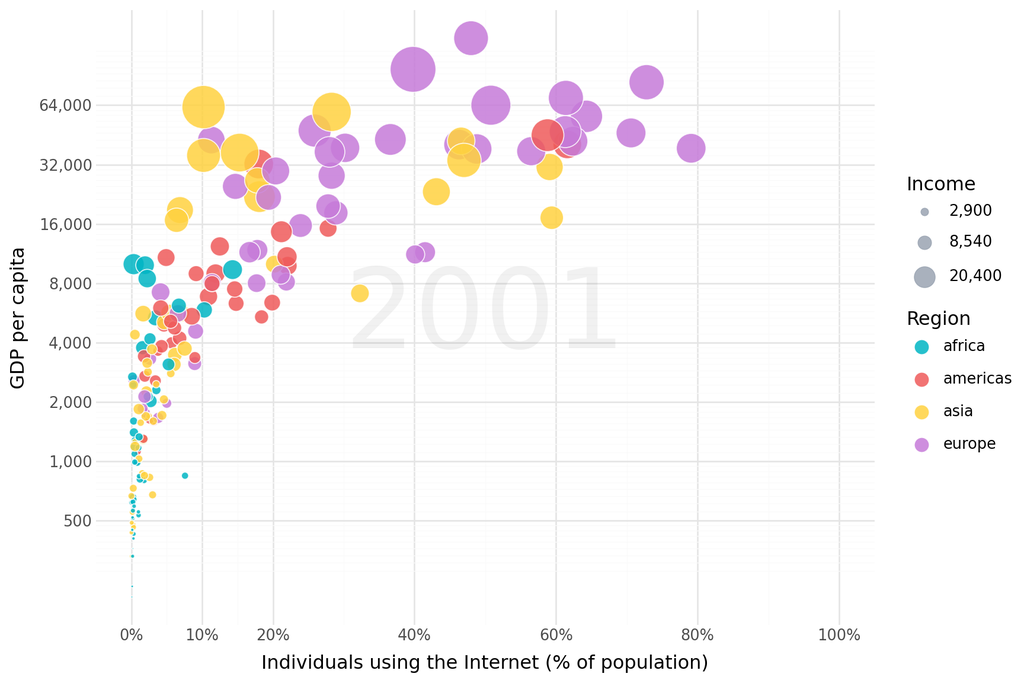

```python
import numpy as np
import pandas as pd
from mizani.formatters import comma_format
from plotnine import (
    ggplot, aes, geom_point, annotate, labs, theme_minimal, theme,
    scale_x_continuous, scale_y_log10, scale_size_area, scale_fill_manual, guides
)
from plotnine.guides import guide_legend

gap_colors = {'africa':'#00B5C4','americas':'#EF5A5A','asia':'#FFD23F','europe':'#C67AD9'}
q3p = (
    q3c.dropna(subset=['internet_users','gdp','income','four_regions'])
       .query('gdp > 0 and income > 0 and 0 <= internet_users <= 100')
       .copy()
)
q3p['four_regions'] = q3p['four_regions'].str.lower()
q3p = q3p[q3p['four_regions'].isin(gap_colors.keys())].copy()
q3p['four_regions'] = q3p['four_regions'].astype('category')

size_brks = list(np.quantile(q3p['income'], [0.25, 0.5, 0.75]))
year_label = int(q3p['year'].mode().iat[0]) if 'year' in q3p.columns else ''

p = (
    ggplot(q3p, aes(x='internet_users', y='gdp', size='income', fill='four_regions'))
    + annotate('text',
               x=50,
               y=np.sqrt(q3p['gdp'].min() * q3p['gdp'].max()),
               label=str(year_label), size=70, alpha=0.08, color='#4d4d4d')
    + geom_point(alpha=0.85, color='white', stroke=0.35)
    + scale_x_continuous(limits=(0, 100),
                         breaks=[0,10,20,40,60,80,100],
                         labels=lambda b: [f'{int(v)}%' for v in b])
    + scale_y_log10(breaks=[500,1000,2000,4000,8000,16000,32000,64000],
                    labels=comma_format())
    + scale_size_area(max_size=16, breaks=size_brks,
                      labels=[f'{int(x):,}' for x in size_brks], guide='legend')
    + scale_fill_manual(values=gap_colors, breaks=list(gap_colors.keys()))
    + labs(x='Individuals using the Internet (% of population)',
           y='GDP per capita',
           fill='Region', size='Income')
    + guides(
        size=guide_legend(order=1,
                          override_aes={'fill':'#9aa4b2','color':'#9aa4b2','alpha':0.85,'stroke':0.3}),
        fill=guide_legend(order=2,
                          override_aes={'size':5,'stroke':0.3,'color':'white'})
    )
    + theme_minimal(base_size=12)
    + theme(figure_size=(9,6))
)

p
```

*3.4:*

For my alternative plot, I chose geom_smooth and geom_rug. The overall trend is shown in the data, but individual observations are not observed. In general, this visualization lacks the insights that the bubble plot does.

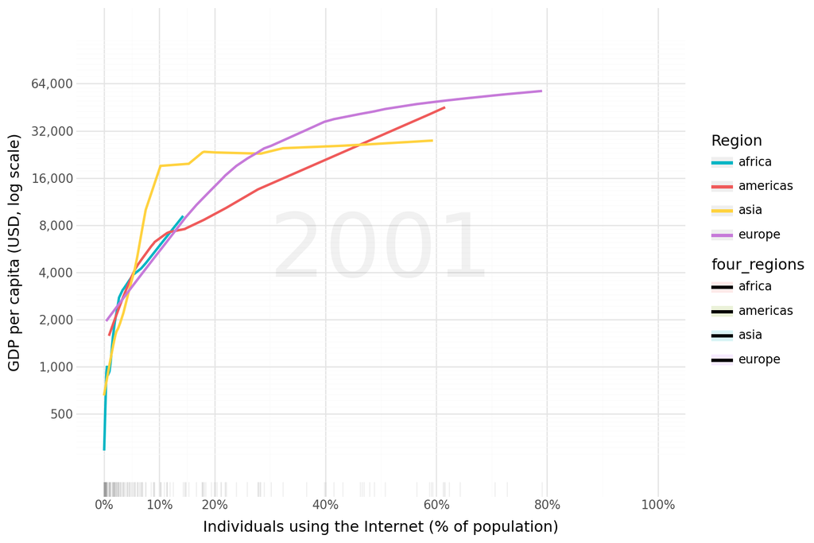

```python
from plotnine import (
    ggplot, aes, geom_smooth, geom_rug, annotate, labs, theme_minimal, theme,
    scale_x_continuous, scale_y_log10, scale_color_manual
)
from mizani.formatters import comma_format
import numpy as np

gap_colors = {'africa':'#00B5C4','americas':'#EF5A5A','asia':'#FFD23F','europe':'#C67AD9'}

p_alt = (
    ggplot(q3p, aes(x='internet_users', y='gdp', color='four_regions', fill='four_regions'))
    + annotate('text',
               x=50,
               y=np.sqrt(q3p['gdp'].min() * q3p['gdp'].max()),
               label='2001', size=70, alpha=0.08, color='#4d4d4d')
    + geom_smooth(method='lowess', se=True, span=0.6, size=1.1, alpha=0.15)
    + geom_rug(sides='b', alpha=0.15, color='#999999')
    + scale_x_continuous(limits=(0,100),
                         breaks=[0,10,20,40,60,80,100],
                         labels=lambda b: [f'{int(v)}%' for v in b])
    + scale_y_log10(breaks=[500,1000,2000,4000,8000,16000,32000,64000],
                    labels=comma_format())
    + scale_color_manual(values=gap_colors)
    + labs(x='Individuals using the Internet (% of population)',
           y='GDP per capita (USD, log scale)',
           color='Region')
    + theme_minimal(base_size=12)
    + theme(figure_size=(9,6))
)
p_alt
```